# SURVEY – meta-analytic practices in neurobiology animal studies

July 2021

## Aims

The main objective of the literature survey was to characterize key meta-analytic practices currently used in papers published in in the field of experimental animal studies in neurology. We aimed for a representative sample of 50-100 meta-analytic papers on non-human animals from the most relevant journals in the field.

## Literature search

We first identified top ranked 10% journals in “Neuroscience” Scopus subject area. This way, we collated a list of 115 journals alongside with their ISSN:

#### Table S1

| Nr | Journal name | ISSN |
| --- | --- | --- |
| 1. | Nature Neuroscience | 1546-1726 |
| 2. | Nature Reviews Neuroscience | 1471-0048 |
| 3. | Nature Reviews Neurology | 1759-4766 |
| 4. | Progress in Retinal and Eye Research | 1873-1635 |
| 5. | Trends in Cognitive Sciences | 1879-307X |
| 6. | Neuron | 1097-4199 |
| 7. | The Lancet Psychiatry | 2215-0374 |
| 8. | Annual Review of Neuroscience | 1545-4126 |
| 9. | Acta Neuropathologica | 1432-0533 |
| 10. | Alzheimer’s and Dementia | 1552-5279 |
| 11. | Molecular Psychiatry | 1476-5578 |
| 12. | Sleep Medicine Reviews | 1532-2955 |
| 13. | Biological Psychiatry | 1873-2402 |
| 14. | Progress in Neurobiology | 1873-5118 |
| 15. | Molecular Neurodegeneration | 1750-1326 |
| 16. | Trends in Neurosciences | 1878-108X |
| 17. | Ageing Research Reviews | 1568-1637 |
| 18. | EMBO Journal | 1460-2075 |
| 19. | Annals of Neurology | 1531-8249 |
| 20. | Neuroscience and Biobehavioral Reviews | 1873-7528 |
| 21. | Frontiers in Neuroendocrinology | 1095-6808 |
| 22. | Movement Disorders | 1531-8257 |
| 23. | Nature Human Behaviour | 2397-3374 |
| 24. | Cellular and Molecular Life Sciences | 1420-9071 |
| 25. | Brain Behavior and Immunity | 1090-2139 |
| 26. | Current Biology | 1879-0445 |
| 27. | Journal of Abnormal Psychology | 1939-843X |
| 28. | Current Opinion in Neurobiology | 1873-6882 |
| 29. | Neuropathology and Applied Neurobiology | 1365-2990 |
| 30. | Epilepsia | 1528-1167 |

[output cut: 85 more lines]

We then used Journal ISSN numbers to create a PubMed search string for the above 115 journals:

1546-1726[Journal] OR 1471-0048[Journal] OR 1759-4766[Journal] OR 1873-1635[Journal] OR 1879-307X[Journal] OR 1097-4199[Journal] OR 2215-0374[Journal] OR 1545-4126[Journal] OR 1432-0533[Journal] OR 1552-5279[Journal] OR 1476-5578[Journal] OR 1532-2955[Journal] OR 1873-2402[Journal] OR 1873-5118[Journal] OR 1750-1326[Journal] OR 1878-108X[Journal] OR 1568-1637[Journal] OR 1460-2075[Journal] OR 1531-8249[Journal] OR 1873-7528[Journal] OR 1095-6808[Journal] OR 1531-8257[Journal] OR 2397-3374[Journal] OR 1420-9071[Journal] OR 1090-2139[Journal] OR 1879-0445[Journal] OR 1939-843X[Journal] OR 1873-6882[Journal] OR 1365-2990[Journal] OR 1528-1167[Journal] OR 1559-7016[Journal] OR 1545-7885[Journal] OR 1879-2782[Journal] OR 2047-9158[Journal] OR 1089-4098[Journal] OR 1098-1136[Journal] OR 2041-4889[Journal] OR 2050-084X[Journal] OR 1095-9572[Journal] OR 1875-6190[Journal] OR 2470-5470[Journal] OR 2373-8057[Journal] OR 1742-2094[Journal] OR 1876-4754[Journal] OR 1559-1182[Journal] OR 0925-2312[Journal] OR 2040-2392[Journal] OR 1477-0970[Journal] OR 1530-888X[Journal] OR 1758-9193[Journal] OR 1750-3639[Journal] OR 1749-6632[Journal] OR 1460-2199[Journal] OR 2352-2895[Journal] OR 1866-3389[Journal] OR 2451-9022[Journal] OR 1866-9964[Journal] OR 1095-953X[Journal] OR 1958-5969[Journal] OR 2158-3188[Journal] OR 1534-6293[Journal] OR 1097-0193[Journal] OR 8686-01X[Journal] OR 1754-8411[Journal] OR 2051-5960[Journal] OR 1528-8447[Journal] OR 1558-1497[Journal] OR 1467-7687[Journal] OR 1090-2430[Journal] OR 1932-846X[Journal] OR 1873-3360[Journal] OR 1558-0210[Journal] OR 1557-1904[Journal] OR 1399-5618[Journal] OR 1469-8749[Journal] OR 2472-1751[Journal] OR 1468-2079[Journal] OR 2352-1546[Journal] OR 1553-7358[Journal] OR 1749-5016[Journal] OR 2213-1582[Journal] OR 1875-8908[Journal] OR 1440-1819[Journal] OR 1939-5086[Journal] OR 2451-9944[Journal] OR 1545-9683[Journal] OR 1872-8952[Journal] OR 1552-5783[Journal] OR 1540-5958[Journal] OR 1939-2222[Journal] OR 1866-1955[Journal] OR 2352-7218[Journal] OR 1873-7838[Journal] OR 1687-5273[Journal] OR 1939-1277[Journal] OR 1873-2364[Journal] OR 1878-6464[Journal] OR 1090-2155[Journal] OR 1438-7573[Journal] OR 1756-8765[Journal] OR 1475-1313[Journal] OR 1540-2010[Journal] OR 1751-7893[Journal] OR 2161-2617[Journal] OR 1873-801X[Journal] OR 1532-7795[Journal] OR 1464-0651[Journal] OR 2327-3801[Journal] OR 1464-5041[Journal] OR 1873-8052[Journal] OR 1943-393X[Journal] OR 2058-458X[Journal] OR 1568-7759[Journal] OR 1873-7994[Journal] OR 1532-7884[Journal]

We note that out of the 115 journal listed above three appeared to not be indexed in PubMed: 1939-843X (Journal of Abnormal Psychology), 8686-01X (Translational Stroke Research), 1873-8052 (Journal of Neurolinguistics). Thus, the search was effectively performed on the remaining 112 journals.

## Inclusion criteria at title and abstract screening phase

- Include studies claiming to be/contain meta-analysis (exclude protocols, methods, opinion articles, corrections, narrative reviews, etc.)
- Include analyses of only animal data or mixed animal and human data (exclude exclusively human-focused studies)
- Include studies with clear neurobiology/biomedical focus, such as experimental preclinical *in vivo* animal research (exclude studies ecological, evolutionary, agricultural or conservation focus).
- Analysed outcomes should be related to neurobiology or behaviour, including meta-analyses of genomic or transcriptomic data, brain imaging.

## Abstract screening procedure and results

We used Rayyan QCRI software to screen 185 unique bibliographic records downloaded from Pubmed. two researchers (YY, ML) independently performed the screening assessing titles abstracts and keywords of each article. This screening resulted in 78 articles included for full-text re-assessment and data data extraction.

## Inclusion criteria at full-text screening

- Full-text studies should fulfill the same criteria as defined for the title and abstract screening phase  
  AND
- Studies to be included for detailed data extraction should be performed using formal meta-analytic methodology (i.e. meta-analytic or meta-regression models combining weighted effect sizes from multiple primary studies (“formal meta analysis”)

## Full text screening and data extraction

Two researchers (YY, ML) independently performed full-text screening was performed concurrently with data extraction using a two-part custom Google Form (https://forms.gle/AYoU1BtkU4PgkmAy9). to pilot the form, randomly selected 14 papers were screened and extracted independently by to researchers (YY, ML). Any potential disagreements were resolved by discussion, and the form was refined as needed, before the main round of independent full-text screening and data extraction.

#### Table S2

| Question | Answer options |
| --- | --- |
| Q1 Is this formal meta-analysis (weighted) of non-human animal studies? | Formal MA; Bioinformatic MA (e.g. transcriptional and genome-wide association studies); Image MA (e.g. fMRI); Self-claiming as containing a meta-analysis (or meta-regression) but actually no formal me… |
| Q2 What is the type of effect sizes used? | SMD (d, g, etc.); raw mean; correlation (r or Zr); Response Ratio (lnRR); variance (VR or lnCVR); 2 by 2 binary data (RR, OR); unclear/other (add comment) |
| Q3 What are the types of statistical models used for MA? | fixed-effect; random-effects; meta-regression (weighted linear-regression); multilevel; multivariate; unclear/other (add comment) |
| Q4 Does the paper account for heterogeneity? | not claiming to account for or explore heterogeneity; accounted by meta-regression, subgroup analysis or stratified MA; unclear/other (add comment) |
| Q5 What are the types of heterogeneity indices reported? | no heterogeneity indices reported; tau^2; Q; H; I^2; Prediction interval; unclear/other (add comment) |
| Q6 Does the study report N (the number of included studies) and k (the number of effect sizes)? | Both reported (add values to the comment); N reported (add values to the comment); k reported (add values to the comment); None reported (add comment) |
| Q7 N | Enter included papers number (N) in the larges statistical analysis/model. If not reported, enter “NA” |
| Q8 k | Enter included effect sizes number (k) in the larges statistical analysis/model. If not reported, enter “NA” |
| Q9 Does the study has the sign of data non-independence? | k/N=1 indicates independent effect sizes; k/N>1 indicates non-independent effect sizes; unclear/other (add comment) |
| Q10 Does the study acknowledge the issue of data non-independence? | Acknowledges effect sizes are not fully independent; Claiming effect sizes are independent; unclear/other (add comment) |
| Q11 Does the paper attempt to address any issues related to data non-independence? | paper explicitly models non-independence (e.g. using multilevel, multivariate models); paper deals with non-independence in other than modelling way (e.g. aggregation, sampling); ignoring or only part… |
| Q12 Does the paper report any approach to control for the sampling error non-independence (e.g. VCV matrix, sample size adjustment)? | VCV matrix; sample size adjustment; cluster-robust standard errors (sandwich robust variance estimation); N/A (it is claimed all data are independent); not controlling for the sampling error non-indep… |
| Q13 What approaches were used to testing for publication bias | Not claiming to do tests for publication bias; Funnel plots; Regression-based methods (e.g., Egger’s test); Fail-safe N; Trim-and-fill tests; Correlation-based methods (e.g., rank); P-value-based meth… |
| Q14 What software was used for analyses? | RevMan; Stata packages; R packages; MetaWin; Comprehensive Meta-Analysis; unclear/other (add comment) |

Each question was followed by a dedicated comment field used to record any additional details, including relevant quotes from the article. Any papers that were coded as “no” at question Q1 (full-text screening question - whether the paper includes a formal meta-analysis of non-human animal data) were excluded, i.e. not subject to further data extraction and analyses.

## Screening results

### Summary tables

#### Table S4

List of articles excluded at full-text screening, with reasons for exclusion.

| First_author | Year | Journal | Title | DOI | Exclusion_reason |
| --- | --- | --- | --- | --- | --- |
| Clark | 2019 | Neuroscience and Biobehavioral Reviews | Ontogeny vs. phylogeny in primate/canid comparisons: A meta-analysis of the object choice task | 10.1016/j.neubiorev.2019.06.001 | Self-claiming as containing a meta-analysis (or meta-regression) but actually no formal meta-analysis/regression was conducted |
| Das | 2020 | Journal of Neuroinflammation | Meta-analysis of mouse transcriptomic studies supports a context-dependent astrocyte reaction in acute CNS injury versus neurodegeneration | 10.1186/s12974-020-01898-y | Bioinformatic MA (e.g. transcriptional and genome-wide association studies) |
| Haage | 2019 | Acta Neuropathologica Communications | Comprehensive gene expression meta- analysis identifies signature genes that distinguish microglia from peripheral monocytes/macrophages in health and glioma | 10.1186/s40478-019-0665-y | Bioinformatic MA (e.g. transcriptional and genome-wide association studies) |
| Hayes | 2014 | Neuroscience and Biobehavioral Reviews | A comparison of neural responses to appetitive and aversive stimuli in humans and other mammals | 10.1016/j.neubiorev.2014.06.018 | Image MA (e.g. fMRI) |
| Hosford | 2019 | Neuroscience and Biobehavioral Reviews | What is the key mediator of the neurovascular coupling response? | 10.1016/j.neubiorev.2018.11.011 | Self-claiming as containing a meta-analysis (or meta-regression) but actually no formal meta-analysis/regression was conducted |
| Huber | 2018 | Journal of Alzheimer's Disease | Cognitive Decline in Preclinical Alzheimer?€?????s Disease: Amyloid-Beta versus Tauopathy | 10.3233/JAD-170490 | Self-claiming as containing a meta-analysis (or meta-regression) but actually no formal meta-analysis/regression was conducted |
| Khorshidi | 2021 | Ageing Research Reviews | Resveratrol: A ?€?miracle?€? drug in neuropsychiatry or a cognitive enhancer for mice only? A systematic review and meta-analysis | 10.1016/j.arr.2020.101199 | Self-claiming as containing a meta-analysis (or meta-regression) but actually no formal meta-analysis/regression was conducted |
| Kole | 2018 | Neuroscience and Biobehavioral Reviews | Cellular diversity of the somatosensory cortical map plasticity | 10.1016/j.neubiorev.2017.11.015 | Bioinformatic MA (e.g. transcriptional and genome-wide association studies) |
| Lee | 2021 | Neuroscience and Biobehavioral Reviews | Meta-analysis of light and circadian timekeeping in rodents | 10.1016/j.neubiorev.2020.12.024 | Self-claiming as containing a meta-analysis (or meta-regression) but actually no formal meta-analysis/regression was conducted |
| Liu | 2020 | Experimental Neurology | Investigation of S-Nitrosoglutathione in stroke: A systematic review and meta-analysis of literature in pre-clinical and clinical research | 10.1016/j.expneurol.2020.113262 | Self-claiming as containing a meta-analysis (or meta-regression) but actually no formal meta-analysis/regression was conducted |

[output cut: 6 more lines]

#### Table S3

List of included articles.

| First_author | Year | Journal | Title | DOI |
| --- | --- | --- | --- | --- |
| Abbott | 2019 | Neuroscience and Biobehavioral Reviews | The effect of high fat, high sugar, and combined high fat-high sugar diets on spatial learning and memory in rodents: A meta-analysis | 10.1016/j.neubiorev.2019.08.010 |
| Aliena-Valero | 2021 | Journal of Cerebral Blood Flow &amp; Metabolism | Effect of uric acid in animal models of ischemic stroke: A systematic review and meta-analysis | 10.1177/0271678X20967459 |
| Antonic | 2013 | PLoS Biology | Stem Cell Transplantation in Traumatic Spinal Cord Injury: A Systematic Review and Meta-Analysis of Animal Studies | 10.1371/journal.pbio.1001738 |
| Antoniuk | 2019 | Neuroscience and Biobehavioral Reviews | Chronic unpredictable mild stress for modeling depression in rodents: Meta- T analysis of model reliability | 10.1016/j.neubiorev.2018.12.002 |
| Barha | 2017 | Frontiers in Neuroendocrinology | Sex differences in aerobic exercise efficacy to improve cognition: A systematic review and meta-analysis of studies in older rodents | 10.1016/j.yfrne.2017.06.001 |
| Belgers | 2016 | Translational Psychiatry | Ibogaine and addiction in the animal model, a systematic review and meta-analysis | 10.1038/tp.2016.71 |
| Bird | 2016 | Neuroscience and Biobehavioral Reviews | Cerebral amyloid- accumulation and deposition following traumatic brain injury?€?A narrative review and meta-analysis of animal studies | 10.1016/j.neubiorev.2016.01.004 |
| Birt | 2021 | Biological Psychiatry | Genetic Liability for Internalizing Versus Externalizing Behavior Manifests in the Developing and Adult Hippocampus: Insight From a Meta-analysis of Transcriptional Profiling Studies in a Selectively … | 10.1016/j.biopsych.2020.05.024 |
| Bonapersona | 2018 | Neuroscience and Biobehavioral Reviews | Effects of early life stress on biochemical indicators of the dopaminergic system: A 3 level meta-analysis of rodent studies | 10.1016/j.neubiorev.2018.09.003 |
| Bonapersona | 2019 | Neuroscience and Biobehavioral Reviews | The behavioral phenotype of early life adversity: A 3-level meta-analysis of T rodent studies | 10.1016/j.neubiorev.2019.04.021 |

[output cut: 52 more lines]

### Preprocessing extracted data

Data cleaning before plotting.

### Plots

#### Publication year

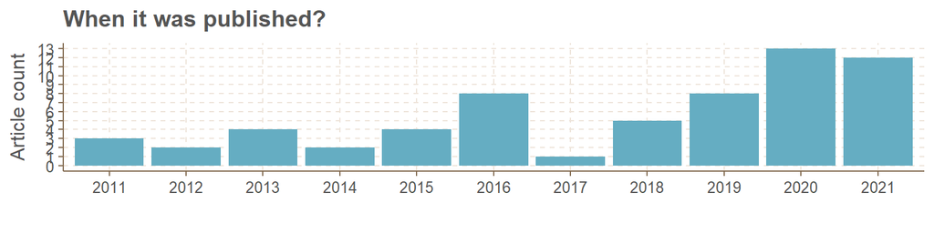

#### Publication journal

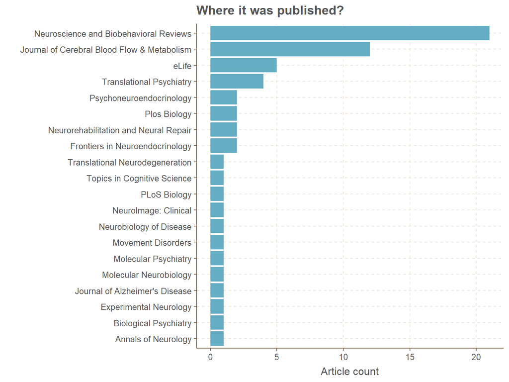

#### Effect size type

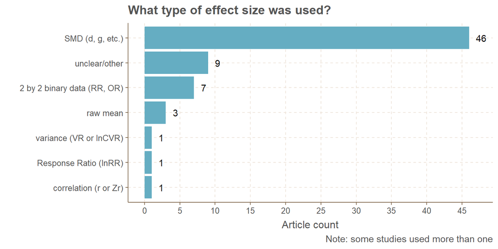

#### Statistical models

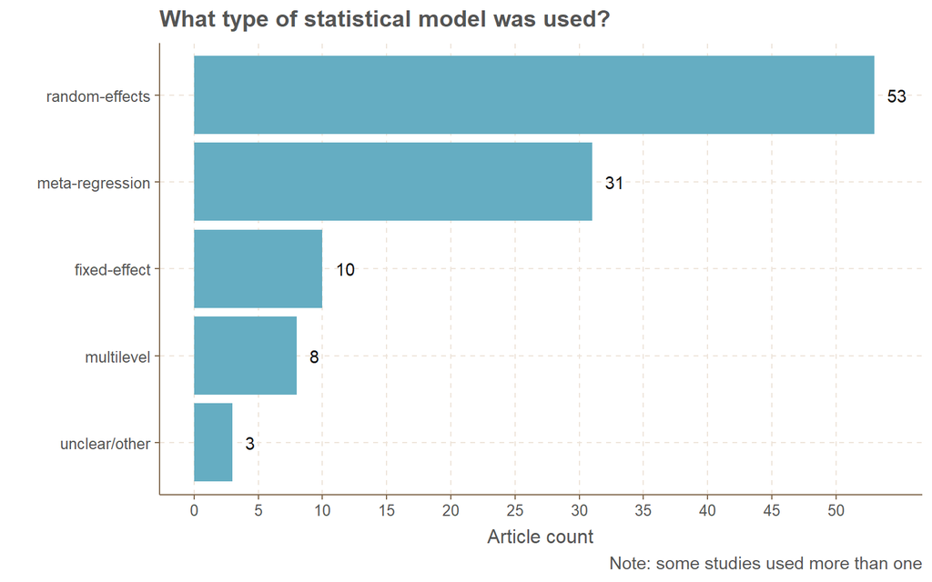

#### Heterogeneity accounted

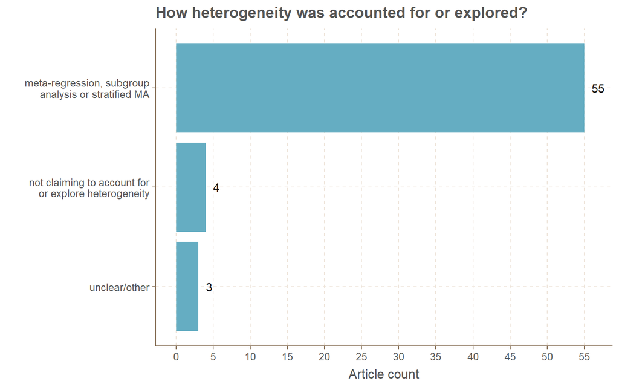

#### Heterogeneity indices

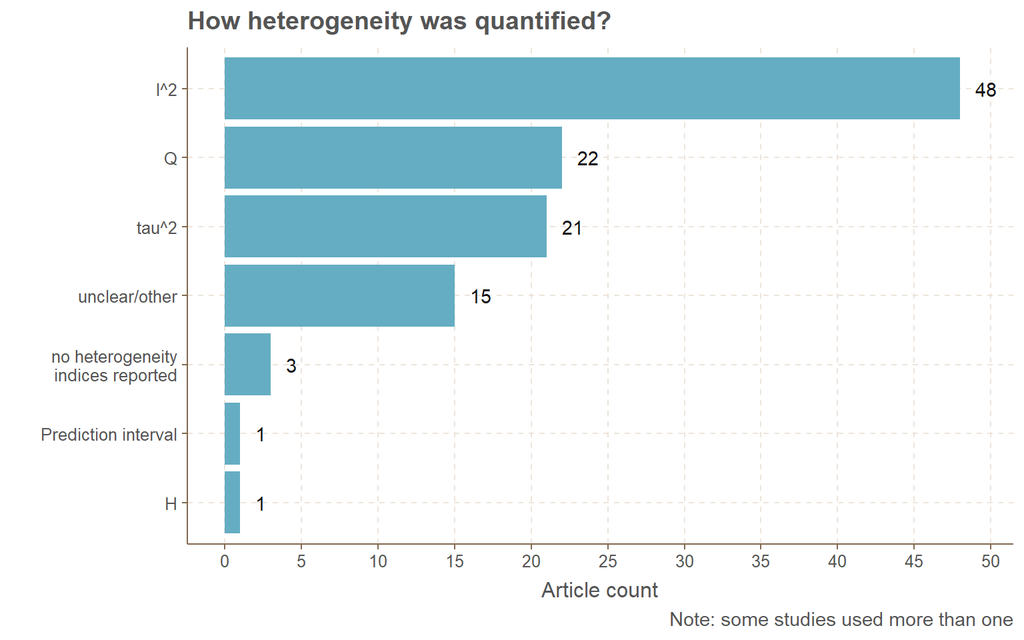

Note: another index that was commonly mentioned was Chi^2.

#### Reporting N and k

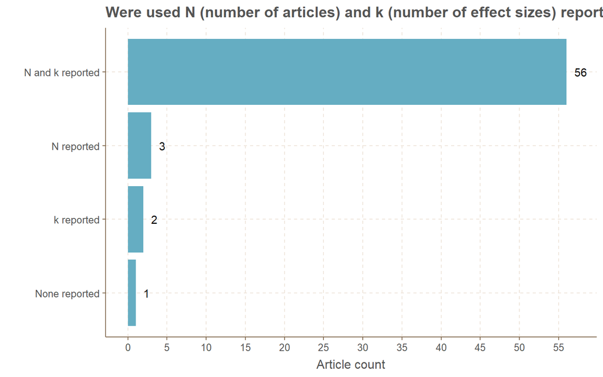

#### Reported N

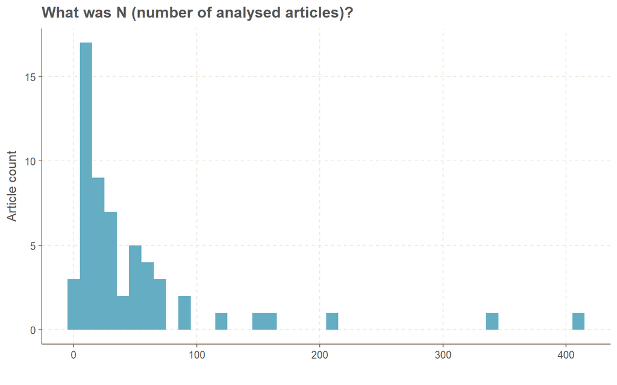

#### Reported k

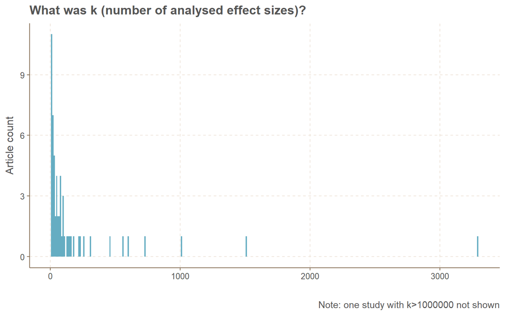

#### Nonindependent data based on k/N ratio

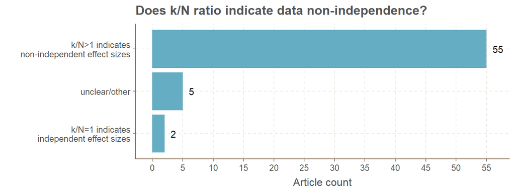

#### Acknowledging non-independence of effect sizes

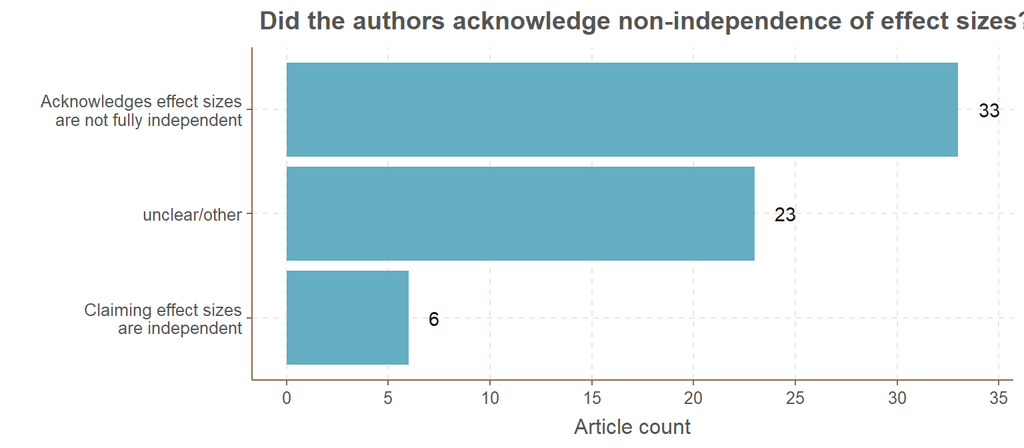

#### Addressing data non-independence

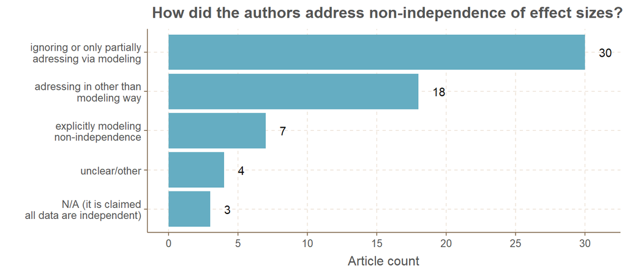

#### Addressing sampling error non-independence

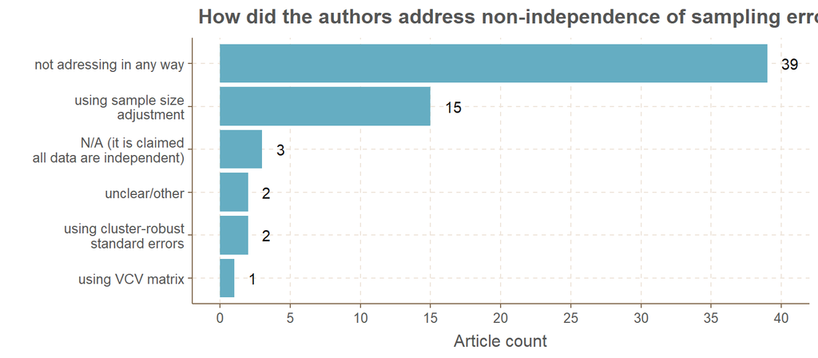

#### testing for publication bias

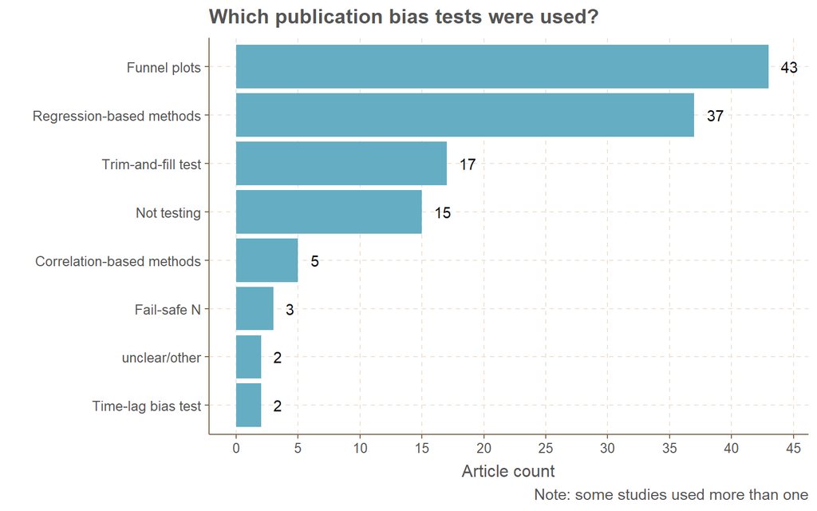

#### Software

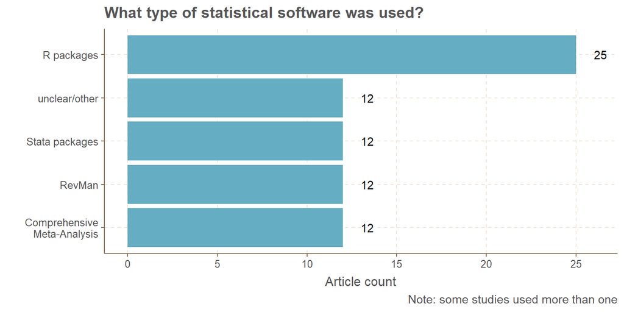

Retrieving additional info on other software and packages used from the comments field.

```
## software2
##       camarades app              dmetar                 jmp              matlab
##                   1                   2                   1                   2
##                meta            metabias             metafor          metaforest
##                   5                   1                  17                   1
##          metamedian             metareg            metatrim             metered
##                   1                   1                   1                   1
##                nlme            robumeta                spss          statistica
##                   1                   2                   5                   2
##                sumz       using stata13 wolfram mathematica
##                   1                   1                   2
```

R package *metafor* was the most used, with 17 mentions. R package *meta came second, with 5 mentions.

## TODO

- select plots for presentation in the main text
- make a multi-panel figure for the main text